# Exon-Cap-Filtering

Jennifer Gardner

7/2/2020

## Create Genious Table

From assembled nf folder File -> new folder -> nf Go to nf folder in explorer -> select all -> drag and drop to import window in genious When asked select import as lists When asked about alignments -> import as separate sequences Will then get a table with summary of number of sequences in each gene Click check mark on upper right of table to select all File -> Export -> selected sequences -> set file type to .csv -> select documents table in genious pop-up (not sequences) to get csv with number of sequences

## Analyze Genious Table

Load dependencies and import table created by genious

```r
library(tidyverse)
sequences <- read.csv("1_assemblednew/assemble_result_supp/4284 documents from nf.csv")
```

```r
head(sequences)
```

```
##                              Name X..Nucleotide.Sequences.With.Mates
## 1 Danio_rerio.1.28199081.28201810                                  0
## 2 Danio_rerio.2.13540557.13540680                                  0
## 3 Danio_rerio.3.32053353.32053508                                  0
## 4 Danio_rerio.5.34112386.34112600                                  0
## 5 Danio_rerio.6.37750492.37750676                                  0
## 6 Danio_rerio.8.13636131.13636394                                  0
##   X..Nucleotides X..Sequences  X.GC                 Created.Date Description
## 1           3891            2 53.2% Thu Jul 02 10:26:12 PDT 2020          NA
## 2            246            2 54.5% Thu Jul 02 10:26:35 PDT 2020          NA
## 3            279            2 63.1% Thu Jul 02 10:26:43 PDT 2020          NA
## 4            420            2 65.2% Thu Jul 02 10:26:46 PDT 2020          NA
## 5            327            2 56.0% Thu Jul 02 10:26:48 PDT 2020          NA
## 6            504            2 57.3% Thu Jul 02 10:26:50 PDT 2020          NA
##               Imported.From..Filename                      Imported.From..Path
```

[output cut: 20 more lines]

```r
sequences$seq.num <- as.factor(sequences$X..Sequences)
length(levels(sequences$seq.num))
```

```
## [1] 97
```

```r
range(sequences$X..Sequences)
```

```
## [1]  2 98
```

```r
seq.counts <- as.data.frame(matrix(NA, nrow = 0, ncol = 2))
for (i in 2:98){
  test.dat <- sequences %>% filter(X..Sequences > i) %>% count()
  row.dat <- c(i,test.dat$n)
  seq.counts <- rbind(seq.counts, row.dat)
}
colnames(seq.counts) <- c("NumSeqGreaterThan", "GenesRetained")
head(seq.counts)
```

```
##   NumSeqGreaterThan GenesRetained
## 1                 2          4209
## 2                 3          4145
## 3                 4          4093
## 4                 5          4046
## 5                 6          4011
## 6                 7          3978
```

```r
tail(seq.counts)
```

```
##    NumSeqGreaterThan GenesRetained
## 92                93          1115
## 93                94           982
## 94                95           808
## 95                96           565
## 96                97           251
## 97                98             0
```

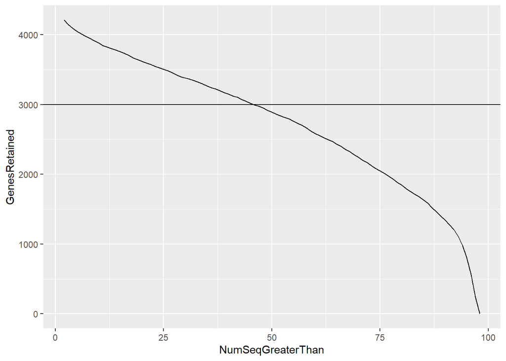

```r
ggplot(seq.counts) + geom_line(aes(x = NumSeqGreaterThan, y = GenesRetained)) + geom_hline(yintercept = 3000)
```

```r
45/98
```

```
## [1] 0.4591837
```

```r
98*.5
```

```
## [1] 49
```

From looking at the seq.count table to retain > 3000 genes (Calder’s level) need to retain genes with >45 sequences. Problem this is accounts for genes captured in fewer than 46% of the sample. To retain genes captured in greater than 50% of the sample, would result in retaining genes with greater than 49 sequences, and retains 2917 genes

##Analyze Output about number of genes per sample

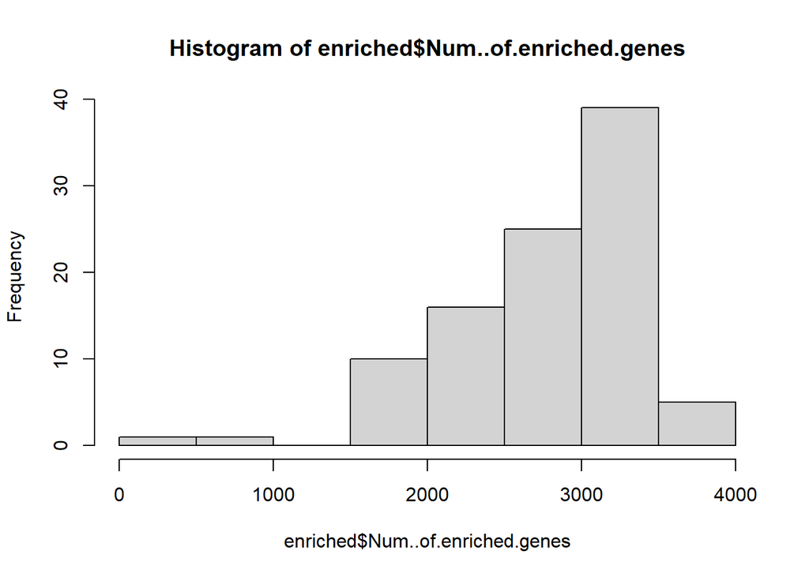

```r
enriched <- read.csv("1_assemblednew/assemble_result_supp/enriched_gene.csv")
hist(enriched$Num..of.enriched.genes)
```

```r
enriched %>% filter(Num..of.enriched.genes <= 1000)
```

```
##               Sample Num..of.enriched.genes Percent.of..Enriched.genes
## 1 CLYC_UW159763_S468                    743                      16.77
## 2 CSPM_UW155719_S413                    382                       8.62
```